# Importing and Cleaning Data in R: Case Studies

# World Food Facts

## Importing the data

```r
# Load data.table
library(data.table)

# Import food.csv: food
url_food <- 'http://s3.amazonaws.com/assets.datacamp.com/production/course_1294/datasets/food.csv'
food <- fread(url_food)

# Convert food to a data frame
food <- data.frame(food)
```

## Examining the data

```r
# Loaded dplyr

# View a glimpse of food
glimpse(food)
```

```
## Observations: 1,500
## Variables: 160
## $ V1                                         <chr> "1", "2", "3", "4",...
## $ code                                       <dbl> 1.592115e-311, 2.67...
## $ url                                        <chr> "http://world-en.op...
## $ creator                                    <chr> "sebleouf", "foodor...
## $ created_t                                  <chr> "1424747544", "1450...
## $ created_datetime                           <chr> "2015-02-24T03:12:2...
## $ last_modified_t                            <chr> "1438445887", "1450...
## $ last_modified_datetime                     <chr> "2015-08-01T16:18:0...
## $ product_name                               <chr> "Confiture de frais...
## $ generic_name                               <chr> "", "", "Pâtes de f...
## $ quantity                                   <chr> "265 g", "375g", "1...
## $ packaging                                  <chr> "Bocal,Verre", "Pla...
## $ packaging_tags                             <chr> "bocal,verre", "pla...
```

[output cut: 147 more lines]

```r
# View column names of food
names(food)
```

```
##   [1] "V1"
##   [2] "code"
##   [3] "url"
##   [4] "creator"
##   [5] "created_t"
##   [6] "created_datetime"
##   [7] "last_modified_t"
##   [8] "last_modified_datetime"
##   [9] "product_name"
##  [10] "generic_name"
##  [11] "quantity"
##  [12] "packaging"
##  [13] "packaging_tags"
##  [14] "brands"
##  [15] "brands_tags"
```

[output cut: 145 more lines]

- sheesh, this is a lot of variables

## Inspecting variables

- I really don’t want to print this all out in the doc so I am limiting the variables here

```r
# View summary of food
summary(food[,1:10])
```

```
##       V1                 code       url              creator
##  Length:1500        Min.   :0   Length:1500        Length:1500
##  Class :character   1st Qu.:0   Class :character   Class :character
##  Mode  :character   Median :0   Mode  :character   Mode  :character
##                     Mean   :0
##                     3rd Qu.:0
##                     Max.   :0
##   created_t         created_datetime   last_modified_t
##  Length:1500        Length:1500        Length:1500
##  Class :character   Class :character   Class :character
##  Mode  :character   Mode  :character   Mode  :character
##
##
##
##  last_modified_datetime product_name       generic_name
##  Length:1500            Length:1500        Length:1500
##  Class :character       Class :character   Class :character
##  Mode  :character       Mode  :character   Mode  :character
##
##
##
```

```r
# View head of food
head(food[,1:10])
```

```
##   V1          code
## 1  1 1.592115e-311
## 2  2 2.673378e-311
## 3  3 1.613001e-311
## 4  4 3.955509e-311
## 5  5 4.189677e-311
## 6  6 4.333113e-313
##                                                                                                                            url
## 1 http://world-en.openfoodfacts.org/product/3222475745867/confiture-de-fraise-fraise-des-bois-au-sucre-de-canne-casino-delices
## 2                                         http://world-en.openfoodfacts.org/product/5410976880110/guylian-sea-shells-selection
## 3                                  http://world-en.openfoodfacts.org/product/3264750423503/pates-de-fruits-aromatisees-jacquot
## 4                                  http://world-en.openfoodfacts.org/product/8006040247001/nata-vegetal-a-base-de-soja-valsoia
## 5           http://world-en.openfoodfacts.org/product/8480000340764/semillas-de-girasol-con-cascara-tostadas-aguasal-hacendado
## 6                                                           http://world-en.openfoodfacts.org/product/0087703177727/soft-drink
##       creator  created_t     created_datetime last_modified_t
```

[output cut: 27 more lines]

```r
# View structure of food
str(food[,1:10])
```

```
## 'data.frame':    1500 obs. of  10 variables:
##  $ V1                    : chr  "1" "2" "3" "4" ...
##  $ code                  : num  1.59e-311 2.67e-311 1.61e-311 3.96e-311 4.19e-311 ...
##  $ url                   : chr  "http://world-en.openfoodfacts.org/product/3222475745867/confiture-de-fraise-fraise-des-bois-au-sucre-de-canne-casino-delices" "http://world-en.openfoodfacts.org/product/5410976880110/guylian-sea-shells-selection" "http://world-en.openfoodfacts.org/product/32647504…
##  $ creator               : chr  "sebleouf" "foodorigins" "domdom26" "javichu" ...
##  $ created_t             : chr  "1424747544" "1450316429" "1428674916" "1420416591" ...
##  $ created_datetime      : chr  "2015-02-24T03:12:24Z" "2015-12-17T01:40:29Z" "2015-04-10T14:08:36Z" "2015-01-05T00:09:51Z" ...
##  $ last_modified_t       : chr  "1438445887" "1450817956" "1428739289" "1420417876" ...
##  $ last_modified_datetime: chr  "2015-08-01T16:18:07Z" "2015-12-22T20:59:16Z" "2015-04-11T08:01:29Z" "2015-01-05T00:31:16Z" ...
##  $ product_name          : chr  "Confiture de fraise fraise des bois au sucre de canne" "Guylian Sea Shells Selection" "Pâtes de fruits aromatisées" "Nata vegetal a base de soja &quot;Valsoia&quot;" ...
##  $ generic_name          : chr  "" "" "Pâtes de fruits" "Nata vegetal a base de soja" ...
```

## Removing dupicate info

- These may be off a bit, this gets rid of the packaging_tags column which is needed later to do the counts of `plasti`

```r
# Define vector of duplicate cols (don't change)
duplicates <- c(4, 6, 11, 13, 15, 17, 18, 20, 22,
                24, 25, 28, 32, 34, 36, 38, 40,
                44, 46, 48, 51, 54, 65, 158)

# Remove duplicates from food: food2
food2 <- food[,-duplicates]
```

## Removing useless info

```r
# Define useless vector (don't change)
useless <- c(1, 2, 3, 32:41)

# Remove useless columns from food2: food3
food3 <- food2[,-useless]
```

## Finding columns

```r
# Create vector of column indices: nutrition
nutrition <- str_detect(names(food3),"100g")

# View a summary of nutrition columns
summary(food3[,nutrition])
```

```
##  energy_from_fat_100g    fat_100g      saturated_fat_100g
##  Min.   :   0.00      Min.   :  0.00   Min.   : 0.000
##  1st Qu.:  35.98      1st Qu.:  0.90   1st Qu.: 0.200
##  Median : 237.00      Median :  6.00   Median : 1.700
##  Mean   : 668.41      Mean   : 13.39   Mean   : 4.874
##  3rd Qu.: 974.00      3rd Qu.: 20.00   3rd Qu.: 6.500
##  Max.   :2900.00      Max.   :100.00   Max.   :57.000
##  NA's   :1486         NA's   :708      NA's   :797
##  butyric_acid_100g caproic_acid_100g caprylic_acid_100g capric_acid_100g
##  Mode:logical      Mode:logical      Mode:logical       Mode:logical
##  NA's:1500         NA's:1500         NA's:1500          NA's:1500
##
##
##
##
##
##  lauric_acid_100g myristic_acid_100g palmitic_acid_100g stearic_acid_100g
##  Mode:logical     Mode:logical       Mode:logical       Mode:logical
##  NA's:1500        NA's:1500          NA's:1500          NA's:1500
##
##
##
##
##
##  arachidic_acid_100g behenic_acid_100g lignoceric_acid_100g
##  Mode:logical        Mode:logical      Mode:logical
##  NA's:1500           NA's:1500         NA's:1500
##
##
##
##
##
##  cerotic_acid_100g montanic_acid_100g melissic_acid_100g
##  Mode:logical      Mode:logical       Mode:logical
##  NA's:1500         NA's:1500          NA's:1500
##
##
##
##
##
```

[output cut: 161 more lines]

```
##  Min.   :12.00                    Min.   :30     Mode:logical
##  1st Qu.:13.50                    1st Qu.:47     NA's:1500
##  Median :15.00                    Median :60
##  Mean   :15.67                    Mean   :57
##  3rd Qu.:17.50                    3rd Qu.:70
##  Max.   :20.00                    Max.   :81
##  NA's   :1497                     NA's   :1491
##  nutrition_score_fr_100g nutrition_score_uk_100g
##  Min.   :-12.000         Min.   :-12.000
##  1st Qu.:  1.000         1st Qu.:  0.000
##  Median :  7.000         Median :  6.000
##  Mean   :  7.941         Mean   :  7.631
##  3rd Qu.: 15.000         3rd Qu.: 16.000
##  Max.   : 28.000         Max.   : 28.000
##  NA's   :825             NA's   :825
```

## Replacing missing values

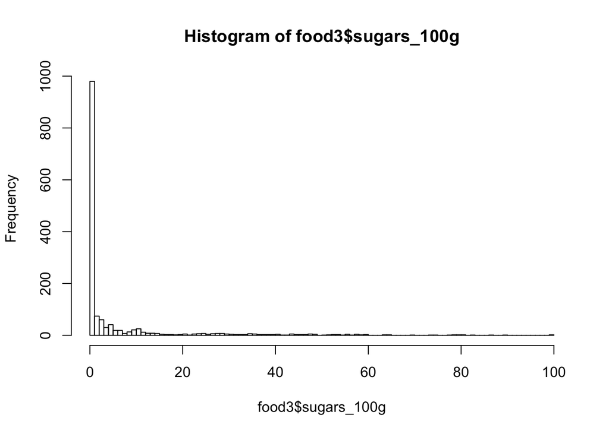

```r
# Find indices of sugar NA values: missing
missing <- is.na(food3$sugars_100g)

# Replace NA values with 0
food3$sugars_100g[missing] <- 0

# Create first histogram
hist(food3$sugars_100g, breaks=100)
```

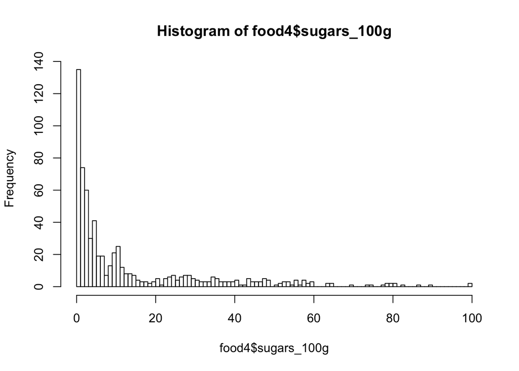

```r
# Create food4
food4 <- food3[food3$sugars_100g != 0, ]

# Create second histogram
hist(food4$sugars_100g, breaks=100)
```

## Dealing with messy data

- This exercise is attempting to estimate the number of food items in plastic packaging
- going back to the original food dataframe here
  - `packagin_tags` column was removed in an earlier exercise. that maybe a mistake

```r
# Find entries containing "plasti": plastic
plastic <- str_detect(food$packaging_tags,"plasti")

# Print the sum of plastic
sum(plastic)
```

```
## [1] 540
```

# School Attendance Data

## Importing the data

```r
# Load the gdata package
library(gdata)

# Import the spreadsheet: att
url_att <- 'http://s3.amazonaws.com/assets.datacamp.com/production/course_1294/datasets/attendance.xls'
att <- read.xls(url_att)
```

## Examining the data

```r
# Print the column names
names(att)
```

```
##  [1] "Table.43..Average.daily.attendance..ADA..as.a.percentage.of.total.enrollment..school.day.length..and.school.year.length.in.public.schools..by.school.level.and.state..2007.08"
##  [2] "X"
##  [3] "X.1"
##  [4] "X.2"
##  [5] "X.3"
##  [6] "X.4"
##  [7] "X.5"
##  [8] "X.6"
##  [9] "X.7"
## [10] "X.8"
## [11] "X.9"
## [12] "X.10"
## [13] "X.11"
## [14] "X.12"
## [15] "X.13"
## [16] "X.14"
## [17] "X.15"
```

```r
# Print the first 6 rows
head(att)
```

```
##   Table.43..Average.daily.attendance..ADA..as.a.percentage.of.total.enrollment..school.day.length..and.school.year.length.in.public.schools..by.school.level.and.state..2007.08
## 1
## 2
## 3                                                                                                                                                                             1
## 4                                                                                                                                                        United States ........
## 5                                                                                                                                                     Alabama .................
## 6                                                                                                                                                     Alaska ..................
##                                                                        X
## 1 Total elementary, secondary, and combined elementary/secondary schools
## 2                                           ADA as percent of enrollment
## 3                                                                      2
## 4                                                                   93.1
## 5                                                                   93.8
## 6                                                                   89.9
##      X.1                         X.2    X.3                         X.4
```

[output cut: 27 more lines]

```r
# Print the last 6 rows
tail(att)
```

```
##                                                                            Table.43..Average.daily.attendance..ADA..as.a.percentage.of.total.enrollment..school.day.length..and.school.year.length.in.public.schools..by.school.level.and.state..2007.08
## 54                                                                                                                                                                                                                             Wisconsin ...............
## 55                                                                                                                                                                                                                             Wyoming .................
## 56                                                                                                                                                                                                                                      †Not applicable.
## 57                                                                                                                                                                                                       ‡Reporting standards not met (too few cases).
## 58 NOTE: Averages reflect data reported by schools rather than state requirements. School-reported length of day may exceed state requirements, and there is a range of statistical error in reported estimates. Standard errors appear in parentheses.
## 59                                                                                                     SOURCE: U.S. Department of Education, National Center for Education Statistics, Schools and Staffing Survey (SASS), \\Public School Questionnaire
##                                                               X    X.1 X.2
## 54                                                         95.0 (0.57) 6.9
## 55                                                         92.4 (1.15) 6.9
## 56
## 57
## 58
## 59 \\ 2003-04 and 2007-08. (This table was prepared June 2011.)
##       X.3 X.4   X.5   X.6   X.7  X.8    X.9 X.10   X.11 X.12   X.13 X.14
## 54 (0.04) 180 (0.7) 1,246 (8.6) 95.4 (0.41)  6.9 (0.05) 93.0 (1.91)  7.0
## 55 (0.05) 175 (1.3) 1,201 (8.3) 92.2 (1.65)  6.9 (0.05) 92.4 (0.75)  7.0
## 56
## 57
## 58
## 59
##      X.15
## 54 (0.14)
## 55 (0.07)
## 56
## 57
## 58
## 59
```

```r
# Print the structure
str(att)
```

```
## 'data.frame':    59 obs. of  17 variables:
##  $ Table.43..Average.daily.attendance..ADA..as.a.percentage.of.total.enrollment..school.day.length..and.school.year.length.in.public.schools..by.school.level.and.state..2007.08: Factor w/ 58 levels "","   United States ........",..: 1 1 5 2 6 7 8 9 10 11 ...
##  $ X                                                                                                                                                                            : Factor w/ 42 levels "","\\ 2003-04 and 2007-08. (This table was prepared June 2011.)",..: 42 41 3 22 28 8 6 14 23 29 ..…
##  $ X.1                                                                                                                                                                          : Factor w/ 45 levels "","(0.22)","(0.23)",..: 1 1 1 2 22 21 41 27 14 6 ...
##  $ X.2                                                                                                                                                                          : Factor w/ 14 levels "","3","6.2","6.3",..: 1 14 2 7 11 6 5 10 3 11 ...
##  $ X.3                                                                                                                                                                          : Factor w/ 14 levels "","(0.02)","(0.03)",..: 1 1 1 2 7 5 9 6 7 5 ...
##  $ X.4                                                                                                                                                                          : Factor w/ 15 levels "","171","172",..: 1 15 14 10 10 10 11 9 11 2 ...
##  $ X.5                                                                                                                                                                          : Factor w/ 22 levels "","(0.0)","(0.1)",..: 1 1 1 3 10 21 19 4 6 12 ...
##  $ X.6                                                                                                                                                                          : Factor w/ 48 levels "","1,102","1,117",..: 1 48 47 26 45 15 13 36 5 28 ...
##  $ X.7                                                                                                                                                                          : Factor w/ 48 levels "","(10.1)","(10.3)",..: 1 1 1 36 11 35 22 6 13 48 ...
##  $ X.8                                                                                                                                                                          : Factor w/ 40 levels "","6","81.0",..: 40 39 2 22 20 9 5 13 27 25 ...
##  $ X.9                                                                                                                                                                          : Factor w/ 51 levels "","(0.24)","(0.25)",..: 1 1 1 4 32 25 48 35 20 13 ...
##  $ X.10                                                                                                                                                                         : Factor w/ 14 levels "","6.2","6.3",..: 1 14 10 7 11 5 4 9 3 11 ...
##  $ X.11                                                                                                                                                                         : Factor w/ 13 levels "","(0.02)","(0.03)",..: 1 1 1 2 8 5 10 8 5 7 ...
##  $ X.12                                                                                                                                                                         : Factor w/ 41 levels "","‡","8","85.8",..: 41 40 3 19 35 30 8 18 9 20 ...
##  $ X.13                                                                                                                                                                         : Factor w/ 47 levels "","(†)","(0.35)",..: 1 1 1 7 5 25 43 35 23 20 ...
##  $ X.14                                                                                                                                                                         : Factor w/ 17 levels "","‡","5.9","6.1",..: 1 17 16 9 14 5 7 11 4 13 ...
##  $ X.15                                                                                                                                                                         : Factor w/ 29 levels "","(†)","(0.03)",..: 1 1 1 4 15 13 21 8 18 9 ...
```

## Removing unnecessary rows

```r
# Create remove
remove <- c(3,56:59)

# Create att2
att2 <- att[-remove,]
```

## Removing useless columns

```r
# Create remove
remove <- seq(3,17,2)

# Create att3
att3 <- att2[,-remove]
```

## Splitting the data

```r
head(att3)
```

```
##   Table.43..Average.daily.attendance..ADA..as.a.percentage.of.total.enrollment..school.day.length..and.school.year.length.in.public.schools..by.school.level.and.state..2007.08
## 1
## 2
## 4                                                                                                                                                        United States ........
## 5                                                                                                                                                     Alabama .................
## 6                                                                                                                                                     Alaska ..................
## 7                                                                                                                                                     Arizona .................
##                                                                        X
## 1 Total elementary, secondary, and combined elementary/secondary schools
## 2                                           ADA as percent of enrollment
## 4                                                                   93.1
## 5                                                                   93.8
## 6                                                                   89.9
## 7                                                                   89.0
##                           X.2                         X.4
```

[output cut: 27 more lines]

```r
# Subset just elementary schools: att_elem
att_elem <- att3[,c(1,6,7)]
head(att_elem)
```

```
##   Table.43..Average.daily.attendance..ADA..as.a.percentage.of.total.enrollment..school.day.length..and.school.year.length.in.public.schools..by.school.level.and.state..2007.08
## 1
## 2
## 4                                                                                                                                                        United States ........
## 5                                                                                                                                                     Alabama .................
## 6                                                                                                                                                     Alaska ..................
## 7                                                                                                                                                     Arizona .................
##                            X.8                        X.10
## 1           Elementary schools
## 2 ADA as percent of enrollment Average hours in school day
## 4                         94.0                         6.7
## 5                         93.8                         7.0
## 6                         91.3                         6.5
## 7                         88.9                         6.4
```

```r
# Subset just secondary schools: att_sec
att_sec <- att3[,c(1,8,9)]
head(att_sec)
```

```
##   Table.43..Average.daily.attendance..ADA..as.a.percentage.of.total.enrollment..school.day.length..and.school.year.length.in.public.schools..by.school.level.and.state..2007.08
## 1
## 2
## 4                                                                                                                                                        United States ........
## 5                                                                                                                                                     Alabama .................
## 6                                                                                                                                                     Alaska ..................
## 7                                                                                                                                                     Arizona .................
##                           X.12                        X.14
## 1            Secondary schools
## 2 ADA as percent of enrollment Average hours in school day
## 4                         91.1                         6.6
## 5                         94.6                         7.1
## 6                         93.2                         6.2
## 7                         89.0                         6.4
```

```r
# Subset all schools: att4
att4 <- att3[,1:5]
head(att4)
```

```
##   Table.43..Average.daily.attendance..ADA..as.a.percentage.of.total.enrollment..school.day.length..and.school.year.length.in.public.schools..by.school.level.and.state..2007.08
## 1
## 2
## 4                                                                                                                                                        United States ........
## 5                                                                                                                                                     Alabama .................
## 6                                                                                                                                                     Alaska ..................
## 7                                                                                                                                                     Arizona .................
##                                                                        X
## 1 Total elementary, secondary, and combined elementary/secondary schools
## 2                                           ADA as percent of enrollment
## 4                                                                   93.1
## 5                                                                   93.8
## 6                                                                   89.9
## 7                                                                   89.0
##                           X.2                         X.4
## 1
## 2 Average hours in school day Average days in school year
## 4                         6.6                         180
## 5                         7.0                         180
## 6                         6.5                         180
## 7                         6.4                         181
##                            X.6
## 1
## 2 Average hours in school year
## 4                        1,193
## 5                        1,267
## 6                        1,163
## 7                        1,159
```

## Replacing the names

```r
# Define cnames vector (don't change)
cnames <- c("state", "avg_attend_pct", "avg_hr_per_day",
            "avg_day_per_yr", "avg_hr_per_yr")

# Assign column names of att4
colnames(att4) <- cnames
head(att4)
```

```
##                       state
## 1
## 2
## 4    United States ........
## 5 Alabama .................
## 6 Alaska ..................
## 7 Arizona .................
##                                                           avg_attend_pct
## 1 Total elementary, secondary, and combined elementary/secondary schools
## 2                                           ADA as percent of enrollment
## 4                                                                   93.1
## 5                                                                   93.8
## 6                                                                   89.9
## 7                                                                   89.0
##                avg_hr_per_day              avg_day_per_yr
## 1
## 2 Average hours in school day Average days in school year
## 4                         6.6                         180
## 5                         7.0                         180
## 6                         6.5                         180
## 7                         6.4                         181
##                  avg_hr_per_yr
## 1
## 2 Average hours in school year
## 4                        1,193
## 5                        1,267
## 6                        1,163
## 7                        1,159
```

```r
# Remove first two rows of att4: att5
att5 <- att4[-c(1,2),]

# View the names of att5
names(att5)
```

```
## [1] "state"          "avg_attend_pct" "avg_hr_per_day" "avg_day_per_yr"
## [5] "avg_hr_per_yr"
```

```r
head(att5)
```

```
##                       state avg_attend_pct avg_hr_per_day avg_day_per_yr
## 4    United States ........           93.1            6.6            180
## 5 Alabama .................           93.8            7.0            180
## 6 Alaska ..................           89.9            6.5            180
## 7 Arizona .................           89.0            6.4            181
## 8 Arkansas ................           91.8            6.9            179
## 9 California ..............           93.2            6.2            181
##   avg_hr_per_yr
## 4         1,193
## 5         1,267
## 6         1,163
## 7         1,159
## 8         1,229
## 9         1,129
```

## Cleaning up extra characters

```r
## stringr and att5 are pre-loaded
head(att5)
```

```
##                       state avg_attend_pct avg_hr_per_day avg_day_per_yr
## 4    United States ........           93.1            6.6            180
## 5 Alabama .................           93.8            7.0            180
## 6 Alaska ..................           89.9            6.5            180
## 7 Arizona .................           89.0            6.4            181
## 8 Arkansas ................           91.8            6.9            179
## 9 California ..............           93.2            6.2            181
##   avg_hr_per_yr
## 4         1,193
## 5         1,267
## 6         1,163
## 7         1,159
## 8         1,229
## 9         1,129
```

```r
# Remove all periods in state column
att5$state <- str_replace_all(att5$state, "\\.","")
head(att5)
```

```
##               state avg_attend_pct avg_hr_per_day avg_day_per_yr
## 4    United States            93.1            6.6            180
## 5          Alabama            93.8            7.0            180
## 6           Alaska            89.9            6.5            180
## 7          Arizona            89.0            6.4            181
## 8         Arkansas            91.8            6.9            179
## 9       California            93.2            6.2            181
##   avg_hr_per_yr
## 4         1,193
## 5         1,267
## 6         1,163
## 7         1,159
## 8         1,229
## 9         1,129
```

```r
# Remove white space around state names
att5$state <- str_trim(att5$state)

# View the head of att5
head(att5)
```

```
##           state avg_attend_pct avg_hr_per_day avg_day_per_yr avg_hr_per_yr
## 4 United States           93.1            6.6            180         1,193
## 5       Alabama           93.8            7.0            180         1,267
## 6        Alaska           89.9            6.5            180         1,163
## 7       Arizona           89.0            6.4            181         1,159
## 8      Arkansas           91.8            6.9            179         1,229
## 9    California           93.2            6.2            181         1,129
```

## Some final type conversions

- dplyr class comes later so this part is just an example here
- This is how you should do it but the not dplyr (old) way is to use sapply

```r
# Change columns to numeric using dplyr (don't change)
library(dplyr)
example <- mutate_each(att5, funs(as.numeric), -state)
str(example)
```

```
## 'data.frame':    52 obs. of  5 variables:
##  $ state         : chr  "United States" "Alabama" "Alaska" "Arizona" ...
##  $ avg_attend_pct: num  22 28 8 6 14 23 29 5 7 11 ...
##  $ avg_hr_per_day: num  7 11 6 5 10 3 11 6 8 10 ...
##  $ avg_day_per_yr: num  10 10 10 11 9 11 2 11 11 11 ...
##  $ avg_hr_per_yr : num  26 45 15 13 36 5 28 19 31 42 ...
```

```r
# Define vector containing numerical columns: cols
cols <- c(2:5)

# Use sapply to coerce cols to numeric
att5[, cols] <- sapply(att5[,cols], as.numeric)
str(att5)
```

```
## 'data.frame':    52 obs. of  5 variables:
##  $ state         : chr  "United States" "Alabama" "Alaska" "Arizona" ...
##  $ avg_attend_pct: num  22 28 8 6 14 23 29 5 7 11 ...
##  $ avg_hr_per_day: num  7 11 6 5 10 3 11 6 8 10 ...
##  $ avg_day_per_yr: num  10 10 10 11 9 11 2 11 11 11 ...
##  $ avg_hr_per_yr : num  26 45 15 13 36 5 28 19 31 42 ...
```